# Question 1.1

# Question 5.1

```r
# Use again the training sets from question 1:
x <- as.matrix(train[,1:16])
y <- as.matrix(train$heart_attack)

data.frame(head(x))
```

```
##    past_pain density age weight height fat_free_wt neck_dim chest_dim abdom_dim
## 2        6.9  1.0853  22 173.25  72.25       161.3     38.5      93.6      83.0
## 3       24.6  1.0414  22 154.00  66.25       116.0     34.0      95.8      87.9
## 4       10.9  1.0751  26 184.75  72.25       164.7     37.4     101.8      86.4
## 7       19.0  1.0549  26 181.00  69.75       146.6     36.4     105.1      90.7
## 8       12.8  1.0704  25 176.00  72.50       153.6     37.8      99.6      88.5
## 10      12.0  1.0722  23 198.25  73.50       174.4     42.1      99.6      88.6
##    hip_dim thigh_dim knee_dim ankle_dim biceps_dim forearm_dim wrist_dim.1
## 2     98.7      58.7     37.3      23.4       30.5        28.9        18.2
## 3     99.2      59.6     38.9      24.0       28.8        25.2        16.6
## 4    101.2      60.1     37.3      22.8       32.4        29.4        18.2
## 7    100.3      58.4     38.3      22.9       31.9        27.8        17.7
## 8     97.1      60.0     39.4      23.2       30.5        29.0        18.8
## 10   104.1      63.1     41.7      25.0       35.6        30.0        19.2
```

```r
# Use glmnet library for lasso CV
library(glmnet)
# Define penalty factor (optional due to same as default settings in glmnet function)
# factor <- c(rep(1, ncol(train)))

# Run CV selection with Lasso penalty
cv_reg <- cv.glmnet(x, y, alpha = 1)  ## alpha = 1 indicating Lasso regression

# Obtain model coefficients given best as biggest λ with avg OOS deviance no more than 1 st.d. from the minimum
coef(cv_reg)
```

```
## 17 x 1 sparse Matrix of class "dgCMatrix"
##                      s1
## (Intercept) -5.42935054
## past_pain    .
## density      .
## age          .
## weight       .
## height       .
## fat_free_wt  .
## neck_dim     .
## chest_dim    0.11976323
## abdom_dim    0.10395778
## hip_dim      0.07758502
## thigh_dim    0.02381018
## knee_dim     .
## ankle_dim    .
## biceps_dim   .
## forearm_dim  .
## wrist_dim.1  .
```

```r
## coef() by default returns betas with 1se lambda
```

- Model with lambda.1se (4 variables selected):

```r
# Obtain lambda_min & lambda_1se values
lambda_min <- cv_reg$lambda.min
lambda_1se <- cv_reg$lambda.1se

lambda_min
```

```
## [1] 0.5422357
```

```r
lambda_1se
```

```
## [1] 0.8633925
```

```r
# Obtain model coefficients given best λ with minimum avg OOS deviance
best_model <- glmnet(x, y, alpha = 1, lambda = lambda_min)
coef(best_model)
```

```
## 17 x 1 sparse Matrix of class "dgCMatrix"
##                      s0
## (Intercept) -9.50011123
## past_pain    .
## density      .
## age          .
## weight       .
## height       .
## fat_free_wt  .
## neck_dim     .
## chest_dim    0.13525431
## abdom_dim    0.10957082
## hip_dim      0.07584114
## thigh_dim    0.05227469
## knee_dim     .
## ankle_dim    .
## biceps_dim   0.01521151
## forearm_dim  .
## wrist_dim.1  .
```

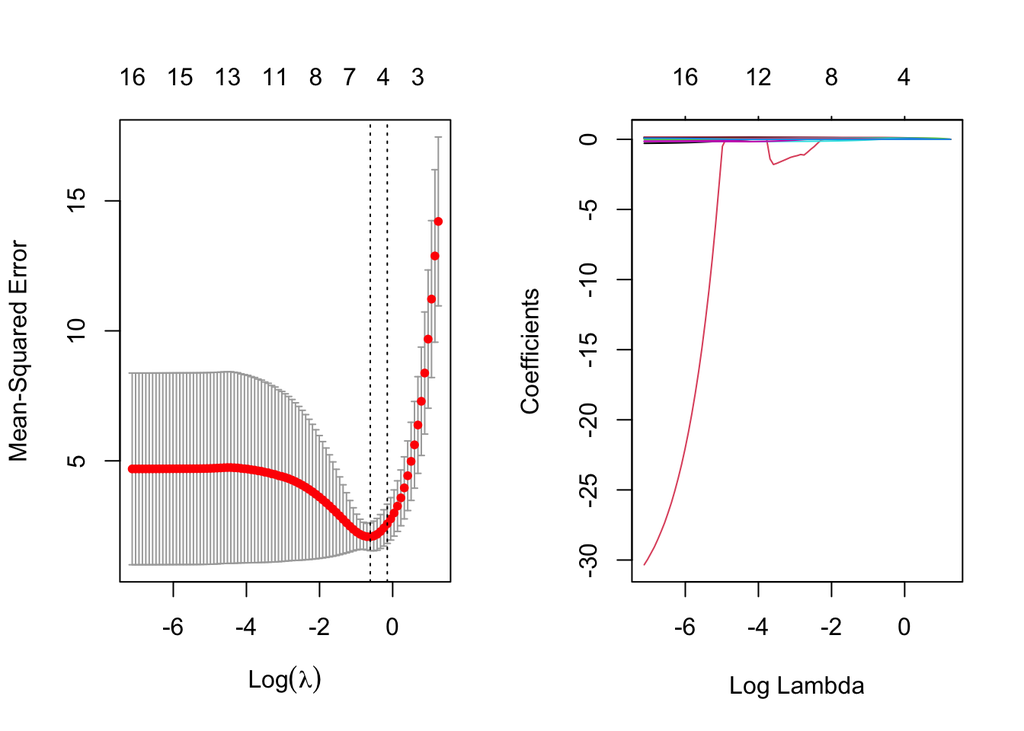

```r
par(mfrow=c(1,2))
plot(cv_reg) ## Plot of MSE by lambda value
plot(cv_reg$glmnet.fit,"lambda") ## Lasso path plots
```

- Among the two models, I would choose the one with lambda_1se, because it has more simplicity than the model with lambda_min. Since cross-validation is not a perfect assessment of OOS performance, a model that is closer to the null model, i.e. a model with less coefficients/betas, is preferred.

# Question 5.2

Compare model outputs from questions one, three, and five:

```r
# Model output from q1: Using 80% observations of raw dataset for training (withou CV)
summary(trained_fit)
```

```
##
## Call:
## lm(formula = heart_attack ~ ., data = train)
##
## Residuals:
##     Min      1Q  Median      3Q     Max
## -4.8249 -0.4403  0.0266  0.6171  2.5429
##
## Coefficients:
##               Estimate Std. Error t value Pr(>|t|)
## (Intercept)  3.618e+01  2.764e+01   1.309 0.192347
## past_pain   -3.213e-01  8.075e-02  -3.980 0.000103 ***
## density     -3.722e+01  2.465e+01  -1.510 0.133055
## age          8.524e-04  8.461e-03   0.101 0.919879
## weight       1.127e-01  2.533e-02   4.451 1.57e-05 ***
## height      -1.336e-01  2.336e-02  -5.719 4.92e-08 ***
## fat_free_wt -1.420e-01  2.977e-02  -4.772 3.99e-06 ***
## neck_dim     1.539e-01  6.059e-02   2.540 0.012012 *
## chest_dim    1.535e-01  2.580e-02   5.947 1.58e-08 ***
## abdom_dim    7.770e-02  2.945e-02   2.639 0.009123 **
## hip_dim      7.507e-02  4.220e-02   1.779 0.077118 .
## thigh_dim    1.035e-01  3.584e-02   2.889 0.004388 **
## knee_dim    -1.415e-01  6.718e-02  -2.106 0.036746 *
## ankle_dim    1.022e-01  5.346e-02   1.912 0.057562 .
## biceps_dim   7.020e-02  4.215e-02   1.666 0.097709 .
## forearm_dim  4.457e-02  4.841e-02   0.921 0.358563
## wrist_dim.1  8.870e-02  1.473e-01   0.602 0.547836
## ---
## Signif. codes:  0 '***' 0.001 '**' 0.01 '*' 0.05 '.' 0.1 ' ' 1
##
## Residual standard error: 0.9507 on 165 degrees of freedom
## Multiple R-squared:  0.9426, Adjusted R-squared:  0.9371
## F-statistic: 169.5 on 16 and 165 DF,  p-value: < 2.2e-16
```

```r
OOS_R_sqr
```

```
## [1] 0.8986206
```

- Q1 fits a full model to predict dependent variable, considering all possible variables x. The model has good performance when testing against the test set, since it has a high OOS R-squared in addition to a high IS R-squared.

```r
# Model output from q3: Estimating 8-fold CV using exactly the same train set from q1
print(model)
```

```
## Linear Regression
##
## 182 samples
##  16 predictor
##
## No pre-processing
## Resampling: Cross-Validated (8 fold)
## Summary of sample sizes: 161, 158, 159, 159, 160, 159, ...
## Resampling results:
##
##   RMSE      Rsquared   MAE
##   1.574568  0.8712675  0.8299211
##
## Tuning parameter 'intercept' was held constant at a value of TRUE
```

- Q3 uses cross-validation to fit the full model, using the same dataset as q1 uses. Its OOS R-squared value is satisfactory, though not as high as the true OOS R^2 of q1 model.

```r
# Model output from q5: Estimating Lasso CV (lambda_1se) with again the same train set
coef(cv_reg)
```

```
## 17 x 1 sparse Matrix of class "dgCMatrix"
##                      s1
## (Intercept) -5.42935054
## past_pain    .
## density      .
## age          .
## weight       .
## height       .
## fat_free_wt  .
## neck_dim     .
## chest_dim    0.11976323
## abdom_dim    0.10395778
## hip_dim      0.07758502
## thigh_dim    0.02381018
## knee_dim     .
## ankle_dim    .
## biceps_dim   .
## forearm_dim  .
## wrist_dim.1  .
```

- Q5 fits a CV Lasso regression to predict y using a “cut model” instead of “full model”. By choosing an appropriate lambda, we select only a few explanatory variables with “best” coefficients that help minimize deviance.

# Question 6

Due to problems with the cross-validation approach, an alternative when choosing lambda is information criteria. Among all ICs, AIC is calculated as AIC = IS Deviance + 2 * df (“degree of freedom” refers to the number of coefficients in fitted model), which approximates OOS Deviance. In selection, a model is recommended if it has the smallest AIC.

However, the problem with AIC is that it tends to overfit in terms of big data. AICc (corrected AIC) is thus introduced to minimize deviance without adding a huge number of parameters. For big n/df, AICc is preferred over AIC. When time is limited, AICc is also preferred as it is fast and stable. It also works nicely in logistic regression, or for any GLM.